# Network Models and Information Theory

Erin M. Buchanan

Last Knitted: 2022-01-24

# Language Topics Discussed

- Network science applied to cognitive science
- Example: NASA Metadata
- But note: this can be applied to any text data in which *n*-gram connections are interesting

# Cognitive Science

- One goal of cognitive scientists is to model semantic memory
  - Previously, we’ve discussed traditional approaches to this task with the hierarchical network and “bubble” models before
  - You can also approach this question using neural network models
- Network science provides a set of tools to help define and explore this structure

# Network terminology

- Nodes: conceptual entities of interest (usually words in our case)
- Edges: relationship between nodes (similarity)
- How do we meaningfully represent these values?
  - Usually we can find data that helps us represent the network we want to build
  - For example, in a semantic network, we can use words as nodes and edges can be represented by shared features, free associations, etc.

# Example Network

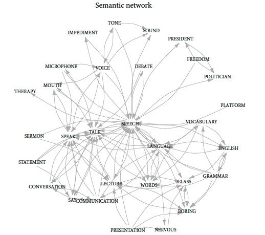

# Network Statistics

- Microscopic Network Measures are often used to denote the importance of a node - or how “central” the node is in the network.
- Degree (k): the number of edges connected to a node, as nodes with more edges are more connected in a network, sometimes called their neighborhood.
- Shortest path distances (L): the shortest distance between two nodes, or how many “hops” you have to take to get between two nodes.

# Network Statistics

- Local clustering coefficient (C): denotes how much the node’s neighbors are also neighbors or the interconnectedness between nodes.

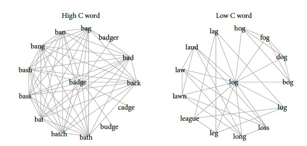

# Network Statistics

- Macroscopic Network Measures are often used to talk about the overall organization of a network.
- Small world structure (S): will have high local clustering coefficients and short path lengths when compared to a random network
  - This idea is sometimes related to efficiency - as things are very closely related, you don’t have to go very far to relay/transmit information.

# Let’s Try Examples

```r
#r chunk
library(jsonlite)
library(dplyr)
```

```r
library(tidytext)
library(widyr)
library(ggplot2)
library(igraph)
library(ggraph)
library(tidyr)
```

# Example: NASA’s metadata

- Metadata is information about what is in a dataset: how it was collected, authors, variable names, variable descriptions, keywords, etc.
- We can use the metadata to simply understand a dataset we want to work with OR treat it as text data itself!
- We will explore NASA’s metadata to see if we can understand its inter-workings.

# What is JSON?

- JSON: JavaScript Object Notation
- A structured file that allows you to store hierarchical information

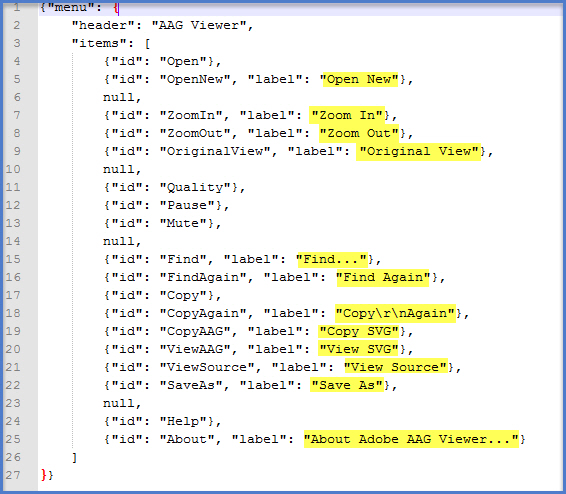

# NASA JSON

```r
##r chunk
metadata <- fromJSON("nasa_data.JSON")
names(metadata$dataset)
```

```
##  [1] "accessLevel"                 "landingPage"
##  [3] "bureauCode"                  "issued"
##  [5] "@type"                       "modified"
##  [7] "references"                  "keyword"
##  [9] "contactPoint"                "publisher"
## [11] "identifier"                  "description"
## [13] "title"                       "programCode"
## [15] "distribution"                "license"
## [17] "accrualPeriodicity"          "theme"
## [19] "citation"                    "temporal"
## [21] "graphic-preview-description" "graphic-preview-file"
## [23] "spatial"                     "language"
## [25] "release-place"               "creator"
## [27] "data-presentation-form"      "series-name"
## [29] "issue-identification"        "describedBy"
## [31] "editor"                      "describedByType"
## [33] "dataQuality"                 "rights"
```

# What data to use?

- We could start with keywords to help us figure out what they think is the most important part of the document.

```r
##r chunk
head(metadata$dataset$keyword) #it's a list!
```

```
## [[1]]
## [1] "international rosetta mission" "earth"
## [3] "unknown"
##
## [[2]]
## [1] "jet propulsion laboratory" "completed"
##
## [[3]]
## [1] "goddard space flight center" "completed"
##
## [[4]]
##  [1] "ngda"                           "soils"
##  [3] "biosphere"                      "ecological dynamics"
##  [5] "earth science"                  "vegetation"
##  [7] "atmospheric water vapor"        "atmospheric radiation"
##  [9] "precipitation"                  "ecosystems"
## [11] "atmospheric temperature"        "atmosphere"
## [13] "land surface"                   "national geospatial data asset"
##
## [[5]]
## [1] "national geospatial data asset" "ngda"
##
## [[6]]
## [1] "near earth asteroid rendezvous" "eros"
```

# What data to use?

- Since this class is all about modeling language, let’s use the titles and descriptions.

```r
##r chunk
head(metadata$dataset$title)
```

```
## [1] "ROSETTA-ORBITER EARTH RPCMAG 2 EAR2 RAW V3.0"
## [2] "Sealed Planetary Return Canister (SPRC), Phase II"
## [3] "Enhanced ORCA and CLARREO Depolarizers Using AR Microstructures, Phase I"
## [4] "LINKAGES: An Individual-based Forest Ecosystem Biogeochemistry Model"
## [5] "ERBE_S4G_MFOV_NF"
## [6] "NEAR EROS RADIO SCIENCE DATA SET - EROS/ORBIT V1.0"
```

```r
head(metadata$dataset$description)
```

```
## [1] "This dataset contains EDITED RAW DATA of the second Earth Flyby (EAR2). The closest approach (CA) took place on November 13, 2007 at 20:57"
## [2] "Sample return missions have primary importance in future planetary missions. A basic requirement is that samples be returned in pristine, uncontaminated condition, necessitating development of a canister system capable of maintaining cleanliness and seal integrity through a variety of enviro…
## [3] "Next generation Earth Science Satellites ORCA and CLARREO are designed to measure our planet's ocean and climate health.  Using hyper-spectral imaging at wavelengths ranging from the UV through NIR, these instruments will record the levels of the earth's temperature rise over the course of a…
## [4] "This model product contains the source codes for version 1 of the individual-based forest ecosystem biogeochemistry model LINKAGES and two subsequent versions as well as example input and output data. LINKAGES predicts long-term structure and dynamics of forest ecosystems as constrained by n…
## [5] "Earth Radiation Budget Experiment (ERBE) S-4G Nonscanner, Medium Field of View (MFOV) Numerical Filter (NF) 5 degree Regional Averages in Hierarchical Data Format"
## [6] "The NEAR Eros Radio Science Data Set is a time-ordered collection of raw and partially processed data collected during the NEAR orbital mapping of the asteroid 433 Eros."
```

# Cleaning up the data

```r
##r chunk
nasa_title <- tibble(id = metadata$dataset$identifier,
                         title = metadata$dataset$title)
head(nasa_title)
```

```
## # A tibble: 6 × 2
##   id                                      title
##   <chr>                                   <chr>
## 1 urn:nasa:pds:context_pds3:data_set:dat… ROSETTA-ORBITER EARTH RPCMAG 2 EAR2 R…
## 2 TECHPORT_9532                           Sealed Planetary Return Canister (SPR…
## 3 TECHPORT_9174                           Enhanced ORCA and CLARREO Depolarizer…
## 4 C179124965-ORNL_DAAC                    LINKAGES: An Individual-based Forest …
## 5 C1000000743-LARC_ASDC                   ERBE_S4G_MFOV_NF
## 6 urn:nasa:pds:context_pds3:data_set:dat… NEAR EROS RADIO SCIENCE DATA SET - ER…
```

# Cleaning up the data

```r
##r chunk
nasa_desc <- tibble(id = metadata$dataset$identifier,
                        desc = metadata$dataset$description)
head(nasa_desc)
```

```
## # A tibble: 6 × 2
##   id                                     desc
##   <chr>                                  <chr>
## 1 urn:nasa:pds:context_pds3:data_set:da… "This dataset contains EDITED RAW DATA…
## 2 TECHPORT_9532                          "Sample return missions have primary i…
## 3 TECHPORT_9174                          "Next generation Earth Science Satelli…
## 4 C179124965-ORNL_DAAC                   "This model product contains the sourc…
## 5 C1000000743-LARC_ASDC                  "Earth Radiation Budget Experiment (ER…
## 6 urn:nasa:pds:context_pds3:data_set:da… "The NEAR Eros Radio Science Data Set …
```

# Cleaning up the data

```r
##r chunk
nasa_keyword <- tibble(id = metadata$dataset$identifier,
                           keyword = metadata$dataset$keyword) %>%
  unnest(keyword)

head(nasa_keyword)
```

```
## # A tibble: 6 × 2
##   id                                                     keyword
##   <chr>                                                  <chr>
## 1 urn:nasa:pds:context_pds3:data_set:data_set.ro-e-rpcm… international rosetta …
## 2 urn:nasa:pds:context_pds3:data_set:data_set.ro-e-rpcm… earth
## 3 urn:nasa:pds:context_pds3:data_set:data_set.ro-e-rpcm… unknown
## 4 TECHPORT_9532                                          jet propulsion laborat…
## 5 TECHPORT_9532                                          completed
## 6 TECHPORT_9174                                          goddard space flight c…
```

# Why separate?

- You could easily merge these together, but that would create lots of duplicates as each dataset has multiple keywords, which we `unnest`ed earlier.
- We will also be breaking each of these down by word, so a bit easier to keep them separate.

```r
##r chunk
nrow(nasa_title)
```

```
## [1] 24349
```

```r
nrow(nasa_desc)
```

```
## [1] 24349
```

```r
nrow(nasa_keyword)
```

```
## [1] 101818
```

# Stop Words and Bag of Words

- We are going to remove all stop words and treat this analysis like a bag of words (each word separately, like the vector space models)

```r
##r chunk
nasa_title <- nasa_title %>%
  unnest_tokens(word, title) %>%
  anti_join(stop_words)
nasa_desc <- nasa_desc %>%
  unnest_tokens(word, desc) %>%
  anti_join(stop_words)
head(nasa_title)
```

```
## # A tibble: 6 × 2
##   id                                                                      word
##   <chr>                                                                   <chr>
## 1 urn:nasa:pds:context_pds3:data_set:data_set.ro-e-rpcmag-2-ear2-raw-v3.0 roset…
## 2 urn:nasa:pds:context_pds3:data_set:data_set.ro-e-rpcmag-2-ear2-raw-v3.0 orbit…
## 3 urn:nasa:pds:context_pds3:data_set:data_set.ro-e-rpcmag-2-ear2-raw-v3.0 earth
## 4 urn:nasa:pds:context_pds3:data_set:data_set.ro-e-rpcmag-2-ear2-raw-v3.0 rpcmag
## 5 urn:nasa:pds:context_pds3:data_set:data_set.ro-e-rpcmag-2-ear2-raw-v3.0 2
## 6 urn:nasa:pds:context_pds3:data_set:data_set.ro-e-rpcmag-2-ear2-raw-v3.0 ear2
```

```r
head(nasa_desc)
```

```
## # A tibble: 6 × 2
##   id                                                                      word
##   <chr>                                                                   <chr>
## 1 urn:nasa:pds:context_pds3:data_set:data_set.ro-e-rpcmag-2-ear2-raw-v3.0 datas…
## 2 urn:nasa:pds:context_pds3:data_set:data_set.ro-e-rpcmag-2-ear2-raw-v3.0 edited
## 3 urn:nasa:pds:context_pds3:data_set:data_set.ro-e-rpcmag-2-ear2-raw-v3.0 raw
## 4 urn:nasa:pds:context_pds3:data_set:data_set.ro-e-rpcmag-2-ear2-raw-v3.0 data
## 5 urn:nasa:pds:context_pds3:data_set:data_set.ro-e-rpcmag-2-ear2-raw-v3.0 earth
## 6 urn:nasa:pds:context_pds3:data_set:data_set.ro-e-rpcmag-2-ear2-raw-v3.0 flyby
```

# Number of Words

- So, how many words are we working with here?

```r
##r chunk
nrow(nasa_title)
```

```
## [1] 198649
```

```r
nrow(nasa_desc)
```

```
## [1] 2273737
```

```r
nrow(nasa_keyword)
```

```
## [1] 101818
```

# Simple statistics

- What are the most popular words?

```r
##r chunk
nasa_title %>%
  count(word, sort = TRUE)
```

```
## # A tibble: 16,088 × 2
##    word       n
##    <chr>  <int>
##  1 phase   8658
##  2 data    2957
##  3 ii      2588
##  4 v1.0    1705
##  5 1       1577
##  6 system  1436
##  7 ges     1212
##  8 disc    1211
##  9 global  1126
## 10 2       1101
## # … with 16,078 more rows
```

# Simple statistics

```r
##r chunk
nasa_desc %>%
  count(word, sort = TRUE)
```

```
## # A tibble: 54,103 × 2
##    word       n
##    <chr>  <int>
##  1 data   35586
##  2 system 16519
##  3 phase  11935
##  4 space   9859
##  5 nasa    8845
##  6 based   8835
##  7 2       8469
##  8 1       7969
##  9 design  7604
## 10 time    7586
## # … with 54,093 more rows
```

# Simple statistics

```r
##r chunk
nasa_keyword %>%
  group_by(keyword) %>%
  count(sort = TRUE)
```

```
## # A tibble: 6,860 × 2
## # Groups:   keyword [6,860]
##    keyword                            n
##    <chr>                          <int>
##  1 completed                       9021
##  2 national geospatial data asset  7262
##  3 ngda                            7262
##  4 earth science                   6948
##  5 active                          2885
##  6 atmosphere                      2734
##  7 land surface                    1673
##  8 goddard space flight center     1537
##  9 glenn research center           1535
## 10 langley research center         1390
## # … with 6,850 more rows
```

# What have we learned?

- NASA seems to report a lot of data because they use open science principles
- They tend to use versioning, which we might consider deleting
- Most everything is in lower case, but you might consider converting case first to ensure all of the same words are matched together

# Exclude numbers

```r
##r chunk
nasa_title <-  nasa_title[-grep("[0-9]", nasa_title$word), ]
nasa_title %>%
  count(word, sort = TRUE)
```

```
## # A tibble: 12,665 × 2
##    word        n
##    <chr>   <int>
##  1 phase    8658
##  2 data     2957
##  3 ii       2588
##  4 system   1436
##  5 ges      1212
##  6 disc     1211
##  7 global   1126
##  8 space    1019
##  9 based     973
## 10 version   861
## # … with 12,655 more rows
```

```r
nasa_desc <-  nasa_desc[-grep("[0-9]", nasa_desc$word), ]
nasa_desc %>%
  count(word, sort = TRUE)
```

```
## # A tibble: 44,792 × 2
##    word        n
##    <chr>   <int>
##  1 data    35586
##  2 system  16519
##  3 phase   11935
##  4 space    9859
##  5 nasa     8845
##  6 based    8835
##  7 design   7604
##  8 time     7586
##  9 systems  7486
## 10 surface  7456
## # … with 44,782 more rows
```

# Collocates!

- What are the common word pairs?

```r
##r chunk
title_word_pairs <- nasa_title %>%
  pairwise_count(word, id, sort = TRUE, upper = FALSE)
head(title_word_pairs)
```

```
## # A tibble: 6 × 3
##   item1 item2      n
##   <chr> <chr>  <dbl>
## 1 phase ii      2498
## 2 ges   disc    1211
## 3 phase system   948
## 4 phase space    637
## 5 phase based    601
## 6 ges   degree   589
```

# Collocates!

```r
##r chunk
desc_word_pairs <- nasa_desc %>%
  pairwise_count(word, id, sort = TRUE, upper = FALSE)

head(desc_word_pairs)
```

```
## # A tibble: 6 × 3
##   item1  item2      n
##   <chr>  <chr>  <dbl>
## 1 data   set     4139
## 2 data   system  3305
## 3 data   time    3144
## 4 phase  ii      3063
## 5 data   nasa    2730
## 6 system nasa    2728
```

# Collocates!

```r
##r chunk
keyword_pairs <- nasa_keyword %>%
  pairwise_count(keyword, id, sort = TRUE, upper = FALSE)

head(keyword_pairs)
```

```
## # A tibble: 6 × 3
##   item1         item2                              n
##   <chr>         <chr>                          <dbl>
## 1 ngda          national geospatial data asset  7262
## 2 ngda          earth science                   6857
## 3 earth science national geospatial data asset  6857
## 4 earth science atmosphere                      2731
## 5 ngda          atmosphere                      2721
## 6 atmosphere    national geospatial data asset  2721
```

# Make a network plot

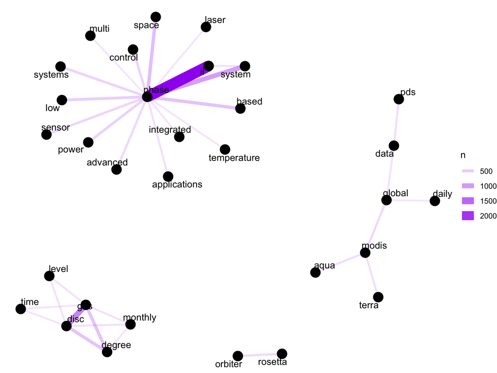

```r
##r chunk
set.seed(52550)
title_word_pairs %>%
  filter(n >= 250) %>%
  graph_from_data_frame() %>%
  ggraph(layout = "fr") + #use ?ggraph to see all the options
  geom_edge_link(aes(edge_alpha = n, edge_width = n), edge_colour = "purple") +
  geom_node_point(size = 5) +
  geom_node_text(aes(label = name), repel = TRUE,
                 point.padding = unit(0.2, "lines")) +
  theme_void()
```

# Make a network plot

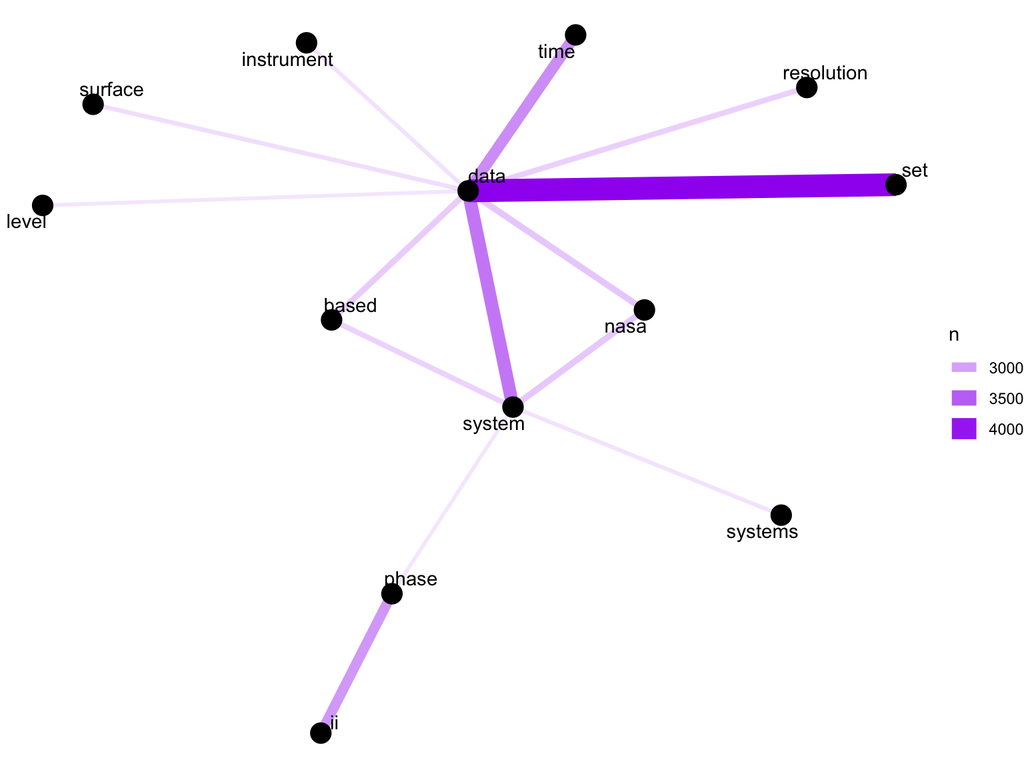

```r
##r chunk
desc_word_pairs %>%
  filter(n >= 2500) %>%
  graph_from_data_frame() %>%
  ggraph(layout = "fr") + #use ?ggraph to see all the options
  geom_edge_link(aes(edge_alpha = n, edge_width = n), edge_colour = "purple") +
  geom_node_point(size = 5) +
  geom_node_text(aes(label = name), repel = TRUE,
                 point.padding = unit(0.2, "lines")) +
  theme_void()
```

# Make a network plot

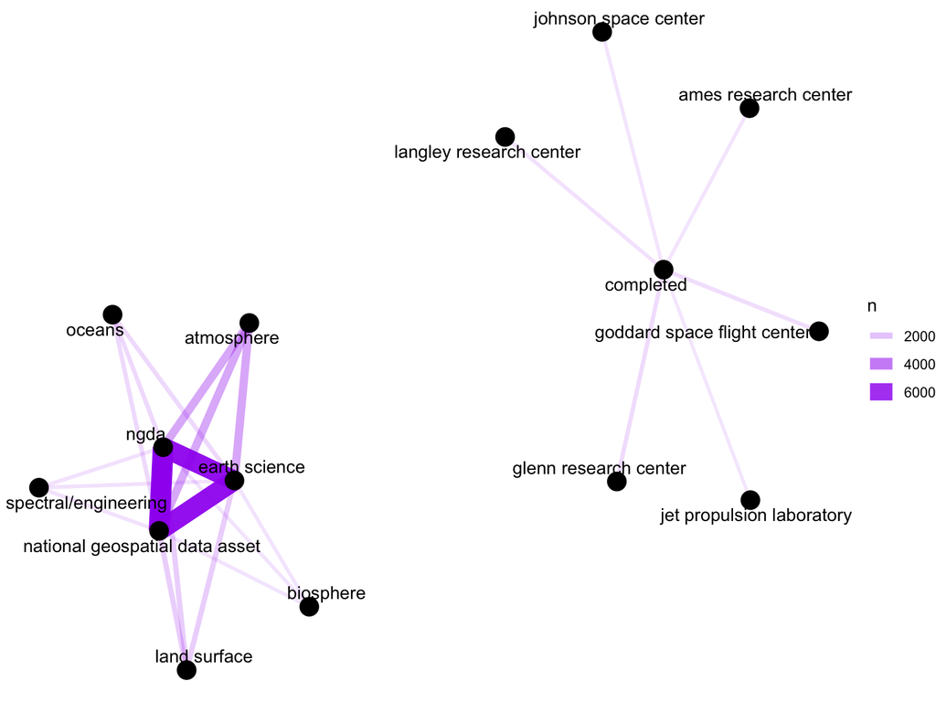

```r
##r chunk
keyword_pairs %>%
  filter(n >= 1000) %>%
  graph_from_data_frame() %>%
  ggraph(layout = "fr") + #use ?ggraph to see all the options
  geom_edge_link(aes(edge_alpha = n, edge_width = n), edge_colour = "purple") +
  geom_node_point(size = 5) +
  geom_node_text(aes(label = name), repel = TRUE,
                 point.padding = unit(0.2, "lines")) +
  theme_void()
```

# Strongest pairs

- What are the strongest word pairs (i.e., they always occur together)?

```r
##r chunk
keyword_cors <- nasa_keyword %>%
  group_by(keyword) %>%
  filter(n() >= 50) %>%
  pairwise_cor(keyword, id, sort = TRUE, upper = FALSE)

head(keyword_cors)
```

```
## # A tibble: 6 × 3
##   item1      item2                          correlation
##   <chr>      <chr>                                <dbl>
## 1 ngda       national geospatial data asset       1
## 2 dashlink   ames                                 1
## 3 knowledge  sharing                              1
## 4 schedule   expedition                           1
## 5 turbulence models                               0.997
## 6 appel      knowledge                            0.997
```

# Visualize correlated pairs

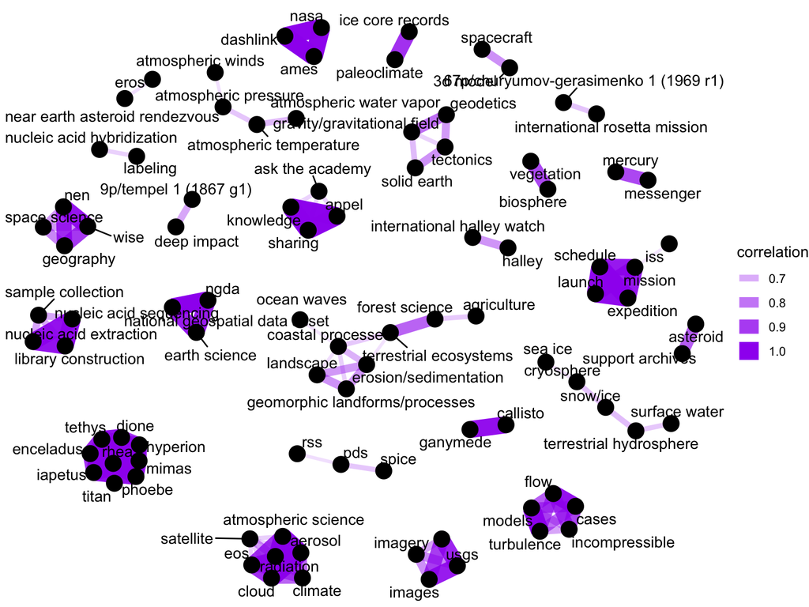

```r
##r chunk
keyword_cors %>%
  filter(correlation > .6) %>%
  graph_from_data_frame() %>%
  ggraph(layout = "fr") +
  geom_edge_link(aes(edge_alpha = correlation, edge_width = correlation), edge_colour = "purple") +
  geom_node_point(size = 5) +
  geom_node_text(aes(label = name), repel = TRUE,
                 point.padding = unit(0.2, "lines")) +
  theme_void()
```

# Network Statistics

- To calculate network statistics, we need to turn our summary table into a long version of the table with all the pairs represented in each row (i.e., one row for each pair combination).

```r
filtered_pairs <- title_word_pairs %>%
  filter(n >= 100)

filtered_long <- filtered_pairs[rep(seq_along(filtered_pairs$n),
                                    filtered_pairs$n), 1:2]

head(filtered_pairs)
```

```
## # A tibble: 6 × 3
##   item1 item2      n
##   <chr> <chr>  <dbl>
## 1 phase ii      2498
## 2 ges   disc    1211
## 3 phase system   948
## 4 phase space    637
## 5 phase based    601
## 6 ges   degree   589
```

```r
head(filtered_long)
```

```
## # A tibble: 6 × 2
##   item1 item2
##   <chr> <chr>
## 1 phase ii
## 2 phase ii
## 3 phase ii
## 4 phase ii
## 5 phase ii
## 6 phase ii
```

# Network Statistics

- Here we find degree (k), or how many edges each node has

```r
degree_calc <- graph.edgelist(as.matrix(filtered_long), directed = T)
# extract degree centrality
degree_summary <- igraph::degree(degree_calc)
degree_summary
```

```
##             phase                ii               ges              disc
##             20627              4069              4685              4684
##            system             space             based            degree
##              1479              1064              1125              2549
##               low             power           systems           control
##               926               700               553               540
##            sensor          advanced            global             modis
##               529               474              2908              2406
##           rosetta           orbiter              aqua              data
##               361               361              1011              4046
##               pds             terra      applications           monthly
##               627               776               544              1479
##             level        integrated       temperature              time
##               750               272               627              1769
##             laser             daily             multi       performance
##               261              1048               254               249
##           thermal        propulsion            design         radiation
##               245               242               237               236
##            ground        validation             fiber              real
##               549               448               230               333
##          analysis               lba               eco           optical
##               228               361               357               226
##               gpm        monitoring       lightweight         composite
##              1410               214               212               204
##            flight           version          aircraft           compact
##               204               390               202               201
##        technology        management           release              grid
##               201               198               350               567
##             array             solar            boreas               ice
##               190               189               187               187
##              tool        spacecraft           cassini       development
##               186               186               528               182
##         detection             merra           gridded              cost
##               182               543              1138               356
##         materials               raw         cryogenic        efficiency
##               176               525               169               167
##        turbulence            models              flow           calipso
##               650               793               652               283
##             ultra     precipitation              heat             lidar
##               162               919               159               423
```

[output cut: 39 more lines]

```
##               112               646               110               110
##            record     manufacturing            imager          improved
##               110               110               540               109
##         satellite             suite             noise      environments
##               213               539               107               107
##            single             hours           product spectroradiometer
##               106               212               105               414
##        processing             cddis               air         automated
##               105               208               104               103
##          wireless          flexible          adaptive          pressure
##               103               102               101               101
##        composites               sea          missions               tes
##               101               100               100               100
##             gprof
##               300
```

# Network Statistics

- What is the central node with the most connections?

```r
head(degree_summary[order(degree_summary, decreasing = T)])
```

```
##  phase    ges   disc     ii   data global
##  20627   4685   4684   4069   4046   2908
```

# Network Statistics

- Betweenness represents how many of the L paths a node is in.
- Therefore, values with high betweenness represent high flow between other nodes.
- Low betweenness indicates that nodes are only connected to a few paths.

```r
betweenness_calc <- igraph::betweenness(degree_calc)

head(betweenness_calc)
```

```
##    phase       ii      ges     disc   system    space
## 154.0000   0.0000 110.9927 110.9663   4.0000   1.0000
```

# Network Statistics

- Closeness represents the average distance from this node to all other nodes, which gives you an idea of the clustering (short path lengths = small world structure with high clustering)

```r
closeness_calc <- igraph::closeness(degree_calc)
head(closeness_calc)
```

```
##         phase            ii           ges          disc        system
## 0.00017241379 0.00005077431 0.00003332667 0.00003312355 0.00002953686
##         space
## 0.00002953686
```

```r
head(closeness_calc[order(closeness_calc, decreasing = T)])
```

```
##     planetary         phase            ii         based           raw
## 0.00018511662 0.00017241379 0.00005077431 0.00004739336 0.00004580642
##       science
## 0.00004580013
```

# What have you learned?

- How to use tidyverse to create bag of words models
- More traditional approaches of network science and statistics
- How to create word networks to visualize related words and their strengths
- Can be combined with work like semantic vector space models to help “show” the data